# Walmart Case Study

By Gautam Naik (gautamnaik1994@gmail.com)  
Github: https://github.com/gautamnaik1994/Walmart-Data-Analysis-case-Study

**About Walmart**

Walmart is an American multinational retail corporation that operates a chain of supercenters, discount departmental stores, and grocery stores from the United States. Walmart has more than 100 million customers worldwide.

**Business Problem**

The Management team at Walmart Inc. wants to analyze the customer purchase behavior (specifically, purchase amount) against the customer’s gender and the various other factors to help the business make better decisions. They want to understand if the spending habits differ between male and female customers: Do women spend more on Black Friday than men? (Assume 50 million customers are male and 50 million are female).

**Metric**

- We will use visualization of all variable with purchase amount to visually confirm our findings.
- Central Limit Theorem with bootstrapping will be used to estimate the confidence interval.
- Hypothesis testing will be done on Gender, Marital Status and Age using z test and t test to answer question about spending patterns

**Dataset**

The company collected the transactional data of customers who purchased products from the Walmart Stores during Black Friday. The dataset has the following features:

- User_ID:User ID
- Product_ID:Product ID
- Gender:Sex of User
- Age:Age in bins
- Occupation:Occupation(Masked)
- City_Category:Category of the City (A,B,C)
- StayInCurrentCityYears:Number of years stay in current city
- Marital_Status: Marital Status
- ProductCategory: Product Category (Masked)
- Purchase:Purchase Amount

**Table of contents**

- Walmart Case Study
- Data Cleaning and Manipulations
- Exploratory Data Analysis
  - Univariate Analysis
  - Bivariate Analysis
  - Multi-variate Analysis
- Hypothesis Testing
  - Effect of Gender on Purchases
    - Define hypothesis
    - Male data analysis
    - Female data analysis
    - Confidence Interval Analysis
    - Plotting
    - 2 sample Z Test
    - T Test
  - Effect of Maritial Status on Purchases
    - Define hypothesis
    - Married user data analysis
    - Single user data analysis
    - Plotting
    - T Test
  - Effect of Age on Purchase
    - Define hypothesis
    - Age Group Analysis
      - Anova Test
- Recommendations

# Data Cleaning and Manipulations

```python
import pandas as pd
import numpy as np
from IPython.core.interactiveshell import InteractiveShell
InteractiveShell.ast_node_interactivity = "all"
import pickle
import seaborn as sns
import matplotlib.pyplot as plt
from scipy.stats import norm,ttest_ind,ttest_1samp,ttest_rel,f_oneway
import concurrent.futures
sns.set_style("whitegrid")
import duckdb as db
```

```python
df=pd.read_csv('./walmart_data.csv')
df.shape
df.head()
df.info()
```

```
(550068, 10)
```

|  | User_ID | Product_ID | Gender | Age | Occupation | City_Category | Stay_In_Current_City_Years | Marital_Status | Product_Category | Purchase |
| --- | --- | --- | --- | --- | --- | --- | --- | --- | --- | --- |
| 0 | 1000001 | P00069042 | F | 0-17 | 10 | A | 2 | 0 | 3 | 8370 |
| 1 | 1000001 | P00248942 | F | 0-17 | 10 | A | 2 | 0 | 1 | 15200 |
| 2 | 1000001 | P00087842 | F | 0-17 | 10 | A | 2 | 0 | 12 | 1422 |
| 3 | 1000001 | P00085442 | F | 0-17 | 10 | A | 2 | 0 | 12 | 1057 |
| 4 | 1000002 | P00285442 | M | 55+ | 16 | C | 4+ | 0 | 8 | 7969 |

```
<class 'pandas.core.frame.DataFrame'>
RangeIndex: 550068 entries, 0 to 550067
Data columns (total 10 columns):
 #   Column                      Non-Null Count   Dtype
---  ------                      --------------   -----
 0   User_ID                     550068 non-null  int64
 1   Product_ID                  550068 non-null  object
 2   Gender                      550068 non-null  object
 3   Age                         550068 non-null  object
 4   Occupation                  550068 non-null  int64
 5   City_Category               550068 non-null  object
 6   Stay_In_Current_City_Years  550068 non-null  object
 7   Marital_Status              550068 non-null  int64
 8   Product_Category            550068 non-null  int64
 9   Purchase                    550068 non-null  int64
dtypes: int64(5), object(5)
memory usage: 42.0+ MB
```

**Observations**

- No null values are present in the dataset.

```python
df.describe()
```

|  | User_ID | Occupation | Marital_Status | Product_Category | Purchase |
| --- | --- | --- | --- | --- | --- |
| count | 5.500680e+05 | 550068.000000 | 550068.000000 | 550068.000000 | 550068.000000 |
| mean | 1.003029e+06 | 8.076707 | 0.409653 | 5.404270 | 9263.968713 |
| std | 1.727592e+03 | 6.522660 | 0.491770 | 3.936211 | 5023.065394 |
| min | 1.000001e+06 | 0.000000 | 0.000000 | 1.000000 | 12.000000 |
| 25% | 1.001516e+06 | 2.000000 | 0.000000 | 1.000000 | 5823.000000 |
| 50% | 1.003077e+06 | 7.000000 | 0.000000 | 5.000000 | 8047.000000 |
| 75% | 1.004478e+06 | 14.000000 | 1.000000 | 8.000000 | 12054.000000 |
| max | 1.006040e+06 | 20.000000 | 1.000000 | 20.000000 | 23961.000000 |

```python
columns=["User_ID","Product_ID","Gender","Age","Occupation","City_Category",\
         "Stay_In_Current_City_Years","Marital_Status","Product_Category","Purchase"]
category_columns=["Gender","City_Category","Marital_Status","Product_Category", "Age",\
                  "Occupation", "User_ID","Product_ID"]
```

```python
print("Unique Values in dataset")
for col in columns:
    print(f"{col} : {df[col].nunique()}")
```

```
Unique Values in dataset
User_ID : 5891
Product_ID : 3631
Gender : 2
Age : 7
Occupation : 21
City_Category : 3
Stay_In_Current_City_Years : 5
Marital_Status : 2
Product_Category : 20
Purchase : 18105
```

```python
df["Age"].value_counts()
```

```
Age
26-35    219587
36-45    110013
18-25     99660
46-50     45701
51-55     38501
55+       21504
0-17      15102
Name: count, dtype: int64
```

```python
df["Occupation"].value_counts()
```

```
Occupation
4     72308
0     69638
7     59133
1     47426
17    40043
20    33562
12    31179
14    27309
2     26588
16    25371
6     20355
3     17650
10    12930
5     12177
15    12165
11    11586
19     8461
13     7728
18     6622
9      6291
8      1546
Name: count, dtype: int64
```

```python
df["Stay_In_Current_City_Years"].value_counts()
```

```
Stay_In_Current_City_Years
1     193821
2     101838
3      95285
4+     84726
0      74398
Name: count, dtype: int64
```

```python
df["Stay_In_Current_City_Years"] = df["Stay_In_Current_City_Years"].replace(to_replace = "4+", value = "4")
df["Stay_In_Current_City_Years"] = df["Stay_In_Current_City_Years"].astype(np.int8)
```

```python
df["Purchase"] = df["Purchase"].astype("int32")
# df["User_ID"] = df["User_ID"].astype("int32")
```

```python
for col in category_columns:
    df[col] = df[col].astype('category')
    # df[col] = df[col].cat.codes
```

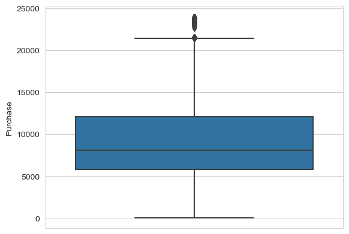

```python
sns.boxplot( y="Purchase", data=df)
```

**Observations**

- There is some outlier data in the dataset.
- We will remove the outlier data by dropping the bottom 5 percentile and above 95 percentile values of Purchase data

```python
five_percentile = np.percentile(df["Purchase"],[5])[0]
ninetyfive_percentile = np.percentile(df["Purchase"],[95])[0]
five_percentile, ninetyfive_percentile
```

```
(1984.0, 19336.0)
```

```python
df=df.loc[(df["Purchase"] > five_percentile) & (df["Purchase"] < ninetyfive_percentile)]
```

```python
df.info()
```

```
<class 'pandas.core.frame.DataFrame'>
Index: 495033 entries, 0 to 545914
Data columns (total 10 columns):
 #   Column                      Non-Null Count   Dtype
---  ------                      --------------   -----
 0   User_ID                     495033 non-null  category
 1   Product_ID                  495033 non-null  category
 2   Gender                      495033 non-null  category
 3   Age                         495033 non-null  category
 4   Occupation                  495033 non-null  category
 5   City_Category               495033 non-null  category
 6   Stay_In_Current_City_Years  495033 non-null  int8
 7   Marital_Status              495033 non-null  category
 8   Product_Category            495033 non-null  category
 9   Purchase                    495033 non-null  int32
dtypes: category(8), int32(1), int8(1)
memory usage: 11.2 MB
```

```python
df.describe(include='category')
```

|  | User_ID | Product_ID | Gender | Age | Occupation | City_Category | Marital_Status | Product_Category |
| --- | --- | --- | --- | --- | --- | --- | --- | --- |
| count | 495033 | 495033 | 495033 | 495033 | 495033 | 495033 | 495033 | 495033 |
| unique | 5891 | 3546 | 2 | 7 | 21 | 3 | 2 | 16 |
| top | 1001680 | P00265242 | M | 26-35 | 4 | B | 0 | 5 |
| freq | 937 | 1843 | 372284 | 198375 | 64892 | 209348 | 292453 | 143987 |

```python
df.describe()
```

|  | Stay_In_Current_City_Years | Purchase |
| --- | --- | --- |
| count | 495033.000000 | 495033.000000 |
| mean | 1.859179 | 9100.472771 |
| std | 1.289395 | 4193.962676 |
| min | 0.000000 | 1985.000000 |
| 25% | 1.000000 | 5987.000000 |
| 50% | 2.000000 | 8047.000000 |
| 75% | 3.000000 | 11796.000000 |
| max | 4.000000 | 19335.000000 |

```python
unique_users=df.drop_duplicates(subset='User_ID')
```

```python
unique_users.info()
```

```
<class 'pandas.core.frame.DataFrame'>
Index: 5891 entries, 0 to 243533
Data columns (total 10 columns):
 #   Column                      Non-Null Count  Dtype
---  ------                      --------------  -----
 0   User_ID                     5891 non-null   category
 1   Product_ID                  5891 non-null   category
 2   Gender                      5891 non-null   category
 3   Age                         5891 non-null   category
 4   Occupation                  5891 non-null   category
 5   City_Category               5891 non-null   category
 6   Stay_In_Current_City_Years  5891 non-null   int8
 7   Marital_Status              5891 non-null   category
 8   Product_Category            5891 non-null   category
 9   Purchase                    5891 non-null   int32
dtypes: category(8), int32(1), int8(1)
memory usage: 466.9 KB
```

```python
with open("data.pickle", "wb") as f:
    pickle.dump(df, f)

with open("unique_users.pickle", "wb") as f:
    df = pickle.dump(unique_users, f)
```

# Exploratory Data Analysis

```python
with open("./data.pickle", "rb") as f:
    df = pickle.load(f)

with open("./unique_users.pickle", "rb") as f:
    unique_users = pickle.load(f)
```

## Univariate Analysis

```python
top_users=db.sql("""
    select User_ID, sum(Purchase) as total_purchase from df group by
        User_ID order by total_purchase desc limit 10
""").to_df()
```

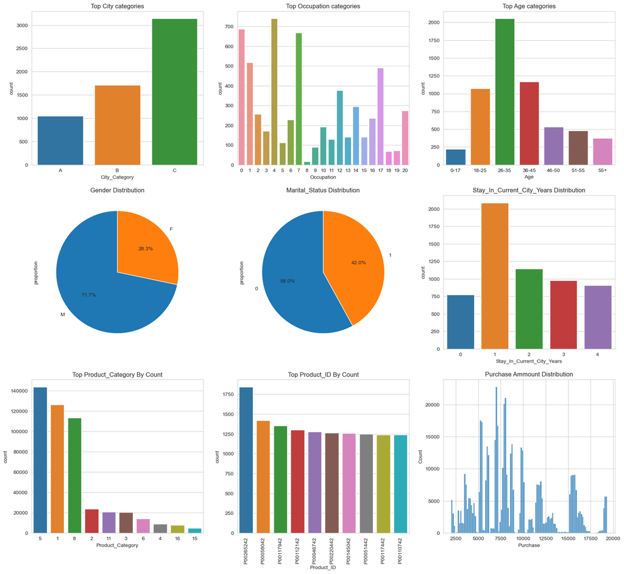

```python
fig, axes = plt.subplots(3, 3, figsize=(20, 18))

sns.countplot(x="City_Category", data=unique_users, ax=axes[0, 0])
axes[0, 0].set_title("Top City categories");

sns.countplot(x="Occupation", data=unique_users , ax=axes[0, 1])
axes[0, 1].set_title("Top Occupation categories");

sns.countplot(x="Age", data=unique_users, ax=axes[0,2])
axes[0,2].set_title("Top Age categories");

unique_users["Marital_Status"].value_counts(normalize=True )[:10].plot(kind="pie", autopct='%1.1f%%', startangle=90, ax=axes[1,1])
axes[1,1].set_title("Marital_Status Distribution");

unique_users["Gender"].value_counts(normalize=True )[:10].plot(kind="pie", autopct='%1.1f%%', startangle=90, ax=axes[1,0])
axes[1,0].set_title("Gender Distribution");

sns.countplot(x="Stay_In_Current_City_Years", data=unique_users, ax=axes[1,2])
axes[1,2].set_title("Stay_In_Current_City_Years Distribution");

sns.countplot(x="Product_Category", data=df, order=df["Product_Category"].value_counts().iloc[:10].index, ax=axes[2,0])
axes[2,0].set_title("Top Product_Category By Count");

sns.countplot(x="Product_ID", data=df, order=df["Product_ID"].value_counts().iloc[:10].index, ax=axes[2,1])
axes[2,1].set_title("Top Product_ID By Count");
plt.setp(axes[2,1].get_xticklabels(), rotation=90)

sns.histplot(x="Purchase", data=df, kde=False, ax=axes[2 , 2])
axes[2,2].set_title("Purchase Ammount Distribution");

plt.show();
```

**Observations**

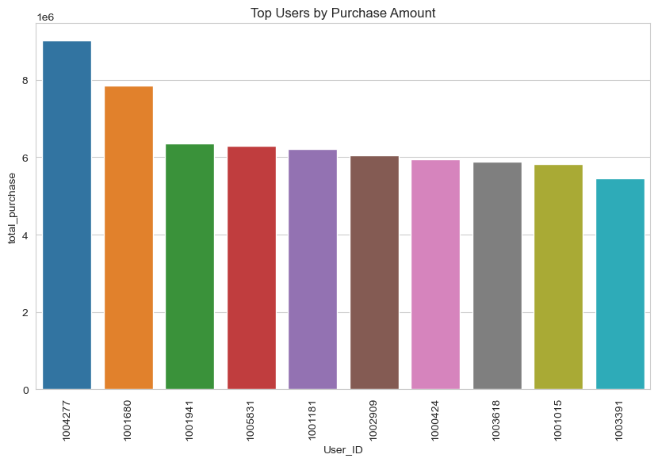

```python
plt.figure(figsize=(10, 6))
sns.barplot(x="User_ID", y="total_purchase" , data=top_users, order=top_users["User_ID"])
plt.title("Top Users by Purchase Amount");
# rotate x tick labels
plt.xticks(rotation=90);
```

**Observations**

- Above table shows the top 10 users who purchased the most products

## Bivariate Analysis

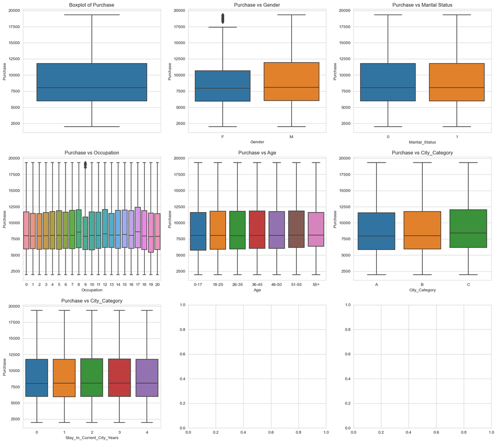

```python
fig, axes = plt.subplots(3, 3, figsize=(20, 18))
sns.boxplot(data=df, y="Purchase", ax=axes[0,0])
axes[0,0].set_title("Boxplot of Purchase");

sns.boxplot(data=df, y="Purchase", x="Gender", ax=axes[0,1])
axes[0,1].set_title("Purchase vs Gender");

sns.boxplot(data=df, y="Purchase", x="Marital_Status", ax=axes[0,2])
axes[0,2].set_title("Purchase vs Marital Status");

sns.boxplot(data=df, x="Occupation", y="Purchase", ax=axes[1,0]);
axes[1,0].set_title("Purchase vs Occupation");

sns.boxplot(data=df, x="Age", y="Purchase", ax=axes[1,1]);
axes[1,1].set_title("Purchase vs Age");

sns.boxplot(data=df, x="City_Category", y="Purchase", ax=axes[1,2]);
axes[1,2].set_title("Purchase vs City_Category");

sns.boxplot(data=df, x="Stay_In_Current_City_Years", y="Purchase", ax=axes[2,0]);
axes[2,0].set_title("Purchase vs City_Category");
```

**Observations**

- No particular pattern is present when purchase data is plotted with other categorical variables.
- Box plots indicate the presense of outlier data.

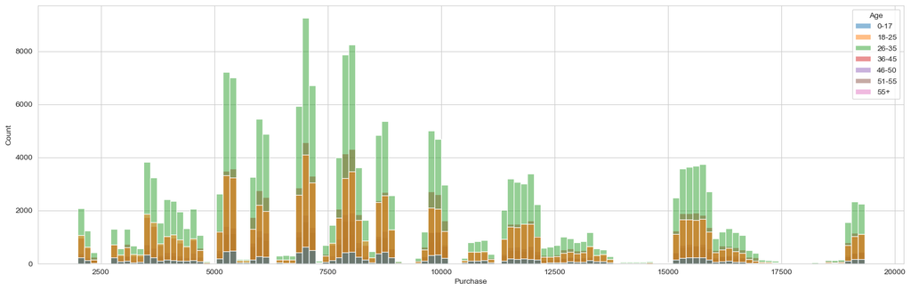

```python
plt.figure(figsize=(20, 6))
sns.histplot(data=df, x="Purchase", hue="Age");
```

**Observations**

- Above plot shows purchase data distribution for all age groups.
- Majority of the spending is between 5000 and 10000 dollars.

## Multi-variate Analysis

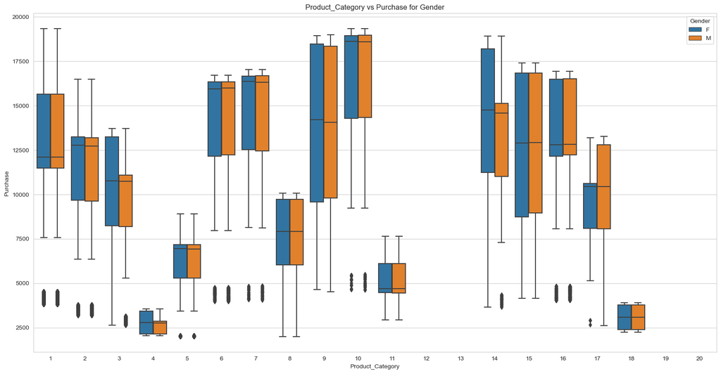

```python
plt.figure(figsize=(20, 10))
sns.boxplot(data=df, x="Product_Category", y="Purchase", hue="Gender");
plt.title("Product_Category vs Purchase for Gender");
```

**Insights**

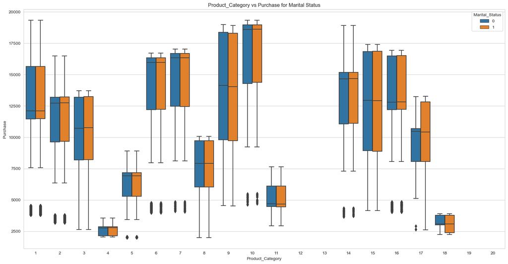

```python
plt.figure(figsize=(20, 10))
sns.boxplot(data=df, x="Product_Category", y="Purchase", hue="Marital_Status");
plt.title("Product_Category vs Purchase for Marital Status");
```

**Insights**

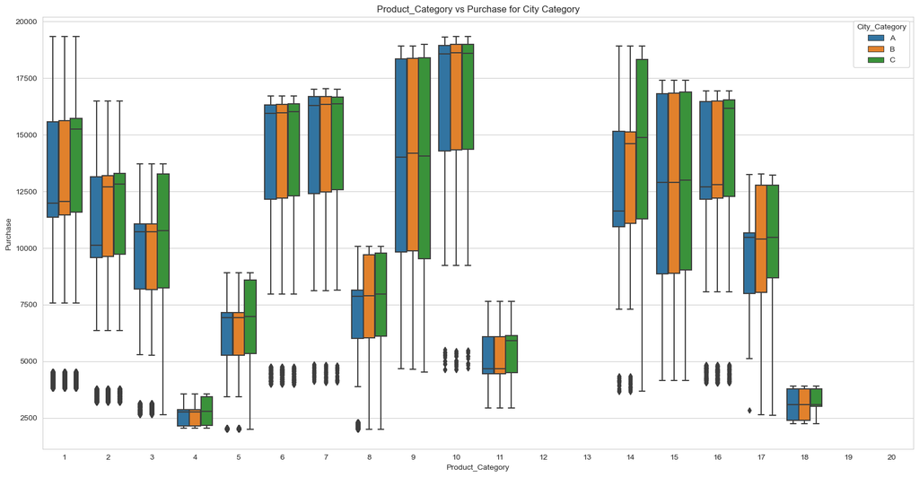

```python
plt.figure(figsize=(20, 10))
sns.boxplot(data=df, x="Product_Category", y="Purchase", hue="City_Category");
plt.title("Product_Category vs Purchase for City Category");
```

**Insights**

- Product Category 14 is most popular in Category C city
- Demand for all product category in all cities seems to be equal

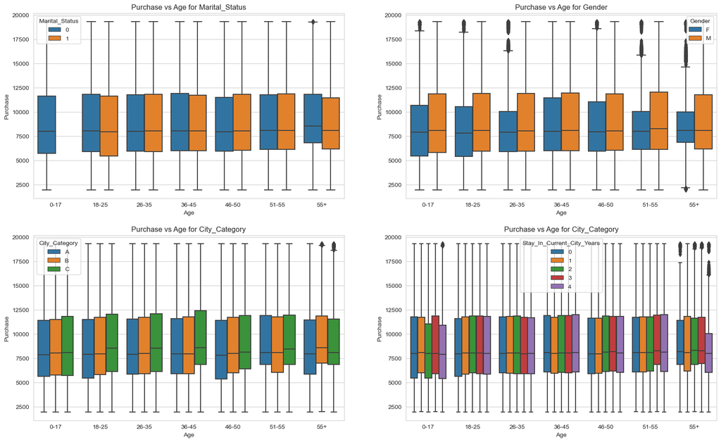

```python
fig, axes = plt.subplots(2, 2, figsize=(20, 12))

sns.boxplot(data=df, x="Age", y="Purchase", hue="Marital_Status", ax=axes[0,0] );
axes[0,0].set_title("Purchase vs Age for Marital_Status");

sns.boxplot(data=df, x="Age", y="Purchase", hue="Gender", ax=axes[0,1]);
axes[0,1].set_title("Purchase vs Age for Gender");

sns.boxplot(data=df, x="Age", y="Purchase", hue="City_Category", ax=axes[1,0]);
axes[1,0].set_title("Purchase vs Age for City_Category");

sns.boxplot(data=df, x="Age", y="Purchase", hue="Stay_In_Current_City_Years", ax=axes[1,1]);
axes[1,1].set_title("Purchase vs Age for City_Category");
```

**Insights**

```python
count_wise_data = db.sql("""
SELECT Age, Product_Category, cnt, rnk_cnt
FROM (
    SELECT
        Age, Product_Category, COUNT(*) AS cnt,
        RANK() OVER (PARTITION BY Age ORDER BY cnt DESC) AS rnk_cnt,
    FROM df
    GROUP BY Age, Product_Category
) AS ranked_data
WHERE rnk_cnt <=3 order by Age, rnk_cnt;
""").to_df()
count_wise_data
```

|  | Age | Product_Category | cnt | rnk_cnt |
| --- | --- | --- | --- | --- |
| 0 | 0-17 | 5 | 4067 | 1 |
| 1 | 0-17 | 1 | 3193 | 2 |
| 2 | 0-17 | 8 | 2252 | 3 |
| 3 | 18-25 | 5 | 26919 | 1 |
| 4 | 18-25 | 1 | 24199 | 2 |
| 5 | 18-25 | 8 | 17823 | 3 |
| 6 | 26-35 | 5 | 58411 | 1 |
| 7 | 26-35 | 1 | 52684 | 2 |
| 8 | 26-35 | 8 | 44067 | 3 |
| 9 | 36-45 | 5 | 28234 | 1 |
| 10 | 36-45 | 1 | 24964 | 2 |
| 11 | 36-45 | 8 | 23222 | 3 |
| 12 | 46-50 | 5 | 11579 | 1 |
| 13 | 46-50 | 8 | 10621 | 2 |
| 14 | 46-50 | 1 | 9411 | 3 |
| 15 | 51-55 | 5 | 9617 | 1 |
| 16 | 51-55 | 8 | 9319 | 2 |
| 17 | 51-55 | 1 | 8043 | 3 |
| 18 | 55+ | 8 | 6194 | 1 |
| 19 | 55+ | 5 | 5160 | 2 |
| 20 | 55+ | 1 | 3916 | 3 |

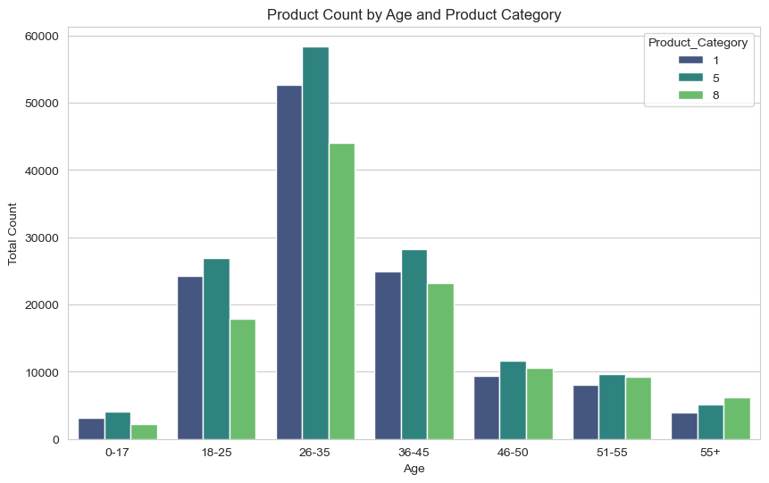

```python
plt.figure(figsize=(10, 6))
sns.barplot(x='Age', y='cnt', hue='Product_Category', data=count_wise_data, palette='viridis')
plt.xlabel('Age')
plt.ylabel('Total Count')
plt.title('Product Count by Age and Product Category');
```

**Insights**

- Above plot shows top products in terms of count for each age group
- Product category 5 is popular product category for all age groups except 55+
- Product category 8 is most popular product category for 55+ age group

```python
purchase_wise_data = db.sql("""
SELECT Age, Product_Category, purchase_total, rnk_total
FROM (
    SELECT
        Age, Product_Category, SUM(Purchase) AS purchase_total,
        RANK() OVER (PARTITION BY Age ORDER BY purchase_total DESC) AS rnk_total
    FROM df
    GROUP BY Age, Product_Category
) AS ranked_data
WHERE rnk_total <= 3  order by Age, rnk_total
""").to_df()
purchase_wise_data
```

|  | Age | Product_Category | purchase_total | rnk_total |
| --- | --- | --- | --- | --- |
| 0 | 0-17 | 1 | 41130457.0 | 1 |
| 1 | 0-17 | 5 | 26573050.0 | 2 |
| 2 | 0-17 | 8 | 17223031.0 | 3 |
| 3 | 18-25 | 1 | 308668603.0 | 1 |
| 4 | 18-25 | 5 | 172230397.0 | 2 |
| 5 | 18-25 | 8 | 132147662.0 | 3 |
| 6 | 26-35 | 1 | 675174790.0 | 1 |
| 7 | 26-35 | 5 | 374041907.0 | 2 |
| 8 | 26-35 | 8 | 327152697.0 | 3 |
| 9 | 36-45 | 1 | 328241666.0 | 1 |
| 10 | 36-45 | 5 | 182463537.0 | 2 |
| 11 | 36-45 | 8 | 175240903.0 | 3 |
| 12 | 46-50 | 1 | 123558710.0 | 1 |
| 13 | 46-50 | 8 | 80199149.0 | 2 |
| 14 | 46-50 | 5 | 75554504.0 | 3 |
| 15 | 51-55 | 1 | 108184920.0 | 1 |
| 16 | 51-55 | 8 | 72550223.0 | 2 |
| 17 | 51-55 | 5 | 63816994.0 | 3 |
| 18 | 55+ | 1 | 52380275.0 | 1 |
| 19 | 55+ | 8 | 48967858.0 | 2 |
| 20 | 55+ | 5 | 34305815.0 | 3 |

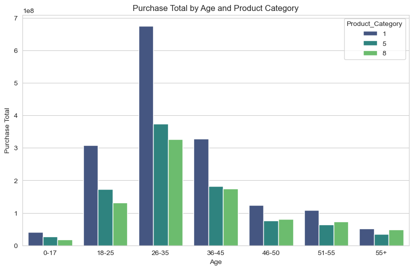

```python
plt.figure(figsize=(10, 6))
sns.barplot(x='Age', y='purchase_total', hue='Product_Category', data=purchase_wise_data, palette='viridis')
plt.xlabel('Age')
plt.ylabel('Purchase Total')
plt.title('Purchase Total by Age and Product Category');
```

**Insights**

- In terms of total purchase amount Product category 1 appears to be the most profitable category among all age groups
- This data can be used to manage the inventory for the stores

```python
purchase_data=db.sql("""
SELECT User_ID, Gender, count(*) cnt, avg(Purchase) avg_purchase
from df group by User_ID, Gender order by cnt desc;
""").to_df()
print("Male")
purchase_data.query("Gender == 'M'").head(10)
print("Female")
purchase_data.query("Gender == 'F'").head(10)
```

```
Male
```

|  | User_ID | Gender | cnt | avg_purchase |
| --- | --- | --- | --- | --- |
| 0 | 1001680 | M | 937 | 8386.797225 |
| 1 | 1004277 | M | 881 | 10224.961407 |
| 2 | 1001181 | M | 817 | 7609.392901 |
| 3 | 1001941 | M | 793 | 8019.283733 |
| 4 | 1000889 | M | 760 | 6765.482895 |
| 5 | 1003618 | M | 737 | 7998.316147 |
| 6 | 1005831 | M | 696 | 9051.349138 |
| 7 | 1001015 | M | 678 | 8576.731563 |
| 8 | 1002063 | M | 659 | 7503.135053 |
| 10 | 1000424 | M | 641 | 9271.140406 |

```
Female
```

|  | User_ID | Gender | cnt | avg_purchase |
| --- | --- | --- | --- | --- |
| 9 | 1001150 | F | 653 | 6809.712098 |
| 17 | 1001088 | F | 624 | 8465.769231 |
| 21 | 1003224 | F | 591 | 9069.399323 |
| 23 | 1003539 | F | 563 | 9558.509769 |
| 25 | 1001605 | F | 544 | 7561.470588 |
| 27 | 1001448 | F | 540 | 8810.890741 |
| 35 | 1005643 | F | 525 | 8216.163810 |
| 36 | 1000752 | F | 518 | 7032.204633 |
| 50 | 1006036 | F | 478 | 7862.179916 |
| 56 | 1002820 | F | 472 | 7531.603814 |

**Insights**

- Both data table shows the average purchase amount and count of sales for top 10 male and female users
- We can see that there is a big difference in count of sales between male and female users.

```python
top_products = db.sql("""
SELECT Product_ID, Product_Category, purchase_total
FROM (
    SELECT
        Product_ID, Product_Category, SUM(Purchase) AS purchase_total,
        RANK() OVER (PARTITION BY Product_Category ORDER BY purchase_total DESC) AS rnk_total
    FROM df
    GROUP BY Product_ID, Product_Category
) AS ranked_data
WHERE rnk_total =1  order by purchase_total desc, Product_Category
""").to_df()
top_products
```

|  | Product_ID | Product_Category | purchase_total |
| --- | --- | --- | --- |
| 0 | P00110742 | 1 | 19441595.0 |
| 1 | P00265242 | 5 | 14096689.0 |
| 2 | P00085942 | 2 | 13325003.0 |
| 3 | P00000142 | 3 | 12837476.0 |
| 4 | P00058042 | 8 | 12248655.0 |
| 5 | P00059442 | 6 | 10221399.0 |
| 6 | P00255842 | 16 | 9315477.0 |
| 7 | P00052842 | 10 | 8064470.0 |
| 8 | P00111742 | 15 | 5016226.0 |
| 9 | P00184242 | 9 | 4622073.0 |
| 10 | P00113042 | 11 | 4267142.0 |
| 11 | P00086842 | 14 | 3518562.0 |
| 12 | P00024042 | 7 | 3393070.0 |
| 13 | P00102642 | 4 | 3350394.0 |
| 14 | P00174842 | 17 | 1775599.0 |
| 15 | P00117542 | 18 | 1710647.0 |

```python
top_products["Product_ID"]= top_products["Product_ID"].astype(str)
```

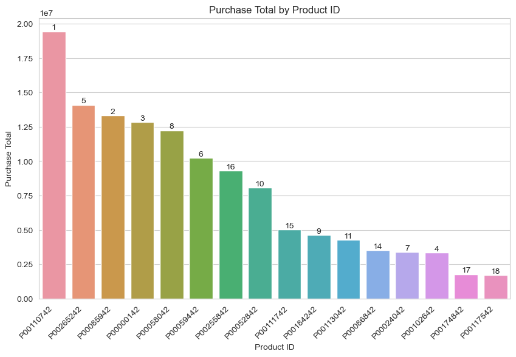

```python
plt.figure(figsize=(10, 6))
ax = sns.barplot(x='Product_ID', y='purchase_total', data=top_products)

for i, row in top_products.iterrows():
    ax.text(i, row['purchase_total'], str(row['Product_Category']), ha='center', va='bottom')

plt.title("Purchase Total by Product ID")
plt.xlabel("Product ID")
plt.ylabel("Purchase Total")
plt.xticks(rotation=45, ha='right')
plt.show();
```

**Insights**

- The category name is printed on top of each bar
- Above plot shows top product for each category in terms of purchase value
- This data can be used to manage the inventory for the stores

```python
top_products_age=db.sql("""
SELECT Age, Product_ID, purchase_total, rnk_total
FROM (
    SELECT
        Age, Product_ID, SUM(Purchase) AS purchase_total,
        RANK() OVER (PARTITION BY Age ORDER BY purchase_total DESC) AS rnk_total
    FROM df
    GROUP BY Age, Product_ID
) AS ranked_data
WHERE rnk_total <= 3  order by Age, rnk_total
""").to_df()
top_products_age["Product_ID"]= top_products_age["Product_ID"].astype(str)
```

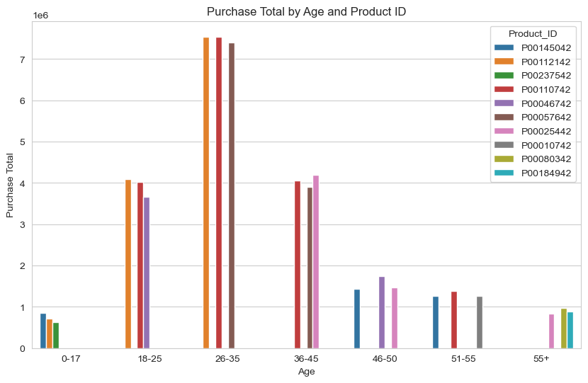

```python
plt.figure(figsize=(10, 6))
sns.barplot(x='Age', y='purchase_total', hue='Product_ID', data=top_products_age)
plt.xlabel('Age')
plt.ylabel('Purchase Total')
plt.title('Purchase Total by Age and Product ID');
```

**Insights**

- Above plot shows top products in terms of sale for each age group
- This data can be used to manage the inventory for the stores

```python
count_wise_age_product_data = db.sql("""
SELECT Age, Product_ID, cnt, rnk_cnt
FROM (
    SELECT
        Age, Product_ID, COUNT(*) AS cnt,
        RANK() OVER (PARTITION BY Age ORDER BY cnt DESC) AS rnk_cnt,
    FROM df
    GROUP BY Age, Product_ID
) AS ranked_data
WHERE rnk_cnt <=3 order by Age, rnk_cnt;
""").to_df()
count_wise_age_product_data["Product_ID"]= count_wise_age_product_data["Product_ID"].astype(str)
count_wise_age_product_data
```

|  | Age | Product_ID | cnt | rnk_cnt |
| --- | --- | --- | --- | --- |
| 0 | 0-17 | P00145042 | 59 | 1 |
| 1 | 0-17 | P00034742 | 56 | 2 |
| 2 | 0-17 | P00000142 | 55 | 3 |
| 3 | 18-25 | P00265242 | 387 | 1 |
| 4 | 18-25 | P00242742 | 265 | 2 |
| 5 | 18-25 | P00112142 | 265 | 2 |
| 6 | 18-25 | P00145042 | 265 | 2 |
| 7 | 26-35 | P00265242 | 732 | 1 |
| 8 | 26-35 | P00058042 | 595 | 2 |
| 9 | 26-35 | P00117942 | 532 | 3 |
| 10 | 36-45 | P00265242 | 308 | 1 |
| 11 | 36-45 | P00058042 | 282 | 2 |
| 12 | 36-45 | P00117942 | 274 | 3 |
| 13 | 46-50 | P00265242 | 135 | 1 |
| 14 | 46-50 | P00051442 | 122 | 2 |
| 15 | 46-50 | P00117942 | 117 | 3 |
| 16 | 46-50 | P00046742 | 117 | 3 |
| 17 | 51-55 | P00265242 | 138 | 1 |
| 18 | 51-55 | P00220442 | 104 | 2 |
| 19 | 51-55 | P00086442 | 101 | 3 |
| 20 | 55+ | P00265242 | 103 | 1 |
| 21 | 55+ | P00051442 | 79 | 2 |
| 22 | 55+ | P00220442 | 67 | 3 |

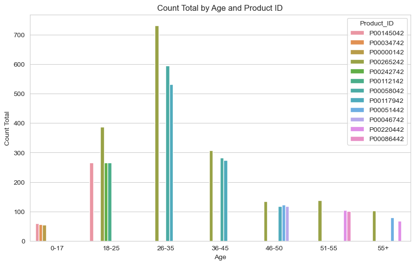

```python
plt.figure(figsize=(10, 6))
sns.barplot(x='Age', y='cnt', hue='Product_ID', data=count_wise_age_product_data)
plt.xlabel('Age')
plt.ylabel('Count Total')
plt.title('Count Total by Age and Product ID');
```

**Insights**

- Above plot shows top products in terms of popularity for each age group

```python
db.sql("""
SELECT Stay_In_Current_City_Years, sum(Purchase) total_purchase
from df group by Stay_In_Current_City_Years order by total_purchase desc;
""").to_df()
```

|  | Stay_In_Current_City_Years | total_purchase |
| --- | --- | --- |
| 0 | 1 | 1.583421e+09 |
| 1 | 2 | 8.394286e+08 |
| 2 | 3 | 7.839477e+08 |
| 3 | 4 | 6.933037e+08 |
| 4 | 0 | 6.049331e+08 |

```python
gender_wise_sale = db.sql("""
SELECT Gender, Product_Category, count(*) cnt from df group by Product_Category, Gender order by cnt desc;
""").to_df()
```

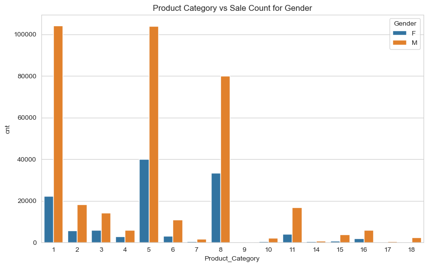

```python
plt.figure(figsize=(10, 6))
sns.barplot(x='Product_Category', y='cnt', hue='Gender', data=gender_wise_sale)
plt.title('Product Category vs Sale Count for Gender');
```

**Insights**

- Above plot shows the difference in count of sales between male and female users for different categories
- There is a big difference in count of sales between male and female users for all categories.

```python
db.sql("""
SELECT Product_Category, COUNT(DISTINCT Product_ID) AS cnt
FROM df
GROUP BY Product_Category
ORDER BY cnt DESC;
""").to_df()
```

|  | Product_Category | cnt |
| --- | --- | --- |
| 0 | 8 | 1046 |
| 1 | 5 | 956 |
| 2 | 1 | 493 |
| 3 | 11 | 248 |
| 4 | 2 | 152 |
| 5 | 6 | 118 |
| 6 | 7 | 101 |
| 7 | 16 | 98 |
| 8 | 3 | 90 |
| 9 | 4 | 88 |
| 10 | 15 | 44 |
| 11 | 14 | 44 |
| 12 | 18 | 30 |
| 13 | 10 | 25 |
| 14 | 17 | 11 |
| 15 | 9 | 2 |

```python
female_products = db.sql("""
SELECT Product_Category, COUNT(DISTINCT Product_ID) AS cnt
FROM df
WHERE Gender = 'F' AND Product_ID NOT IN (SELECT DISTINCT Product_ID FROM df WHERE Gender = 'M')
GROUP BY Product_Category
ORDER BY cnt DESC;

""").to_df()
female_products["Product_Category"]= female_products["Product_Category"].astype(str)
```

```python
male_products = db.sql("""
SELECT Product_Category, COUNT(DISTINCT Product_ID) AS cnt
FROM df
WHERE Gender = 'M' AND Product_ID NOT IN (SELECT DISTINCT Product_ID FROM df WHERE Gender = 'F')
GROUP BY Product_Category
ORDER BY cnt DESC;

""").to_df()
male_products["Product_Category"] = male_products["Product_Category"].astype(str)
```

```python
female_products["Gender"]="F"
male_products["Gender"]="M"
result = pd.concat([female_products, male_products], axis=0, ignore_index=True)
# result
```

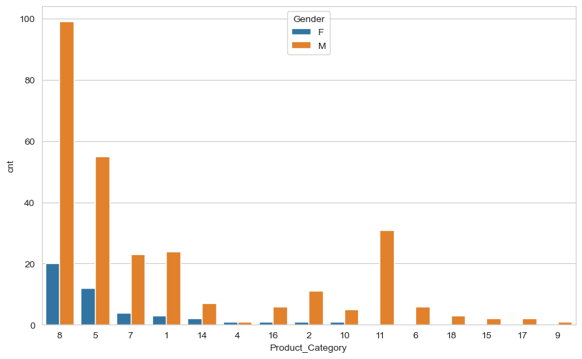

```python
plt.figure(figsize=(10, 6))
sns.barplot(x='Product_Category', y='cnt', hue="Gender" ,data=result);
```

**Insights**

- Above plot show the count of unique products that is used by only 1 gender in a given category.
- We can see that there are lot less female only products than male products.
- This might be one of the reasons why there are more male users

```python
city_sales = db.sql("""
SELECT City_Category, sum(Purchase) total_purchase, count(*) from df group by City_Category order by total_purchase desc;
""").to_df()
city_sales
```

|  | City_Category | total_purchase | count_star() |
| --- | --- | --- | --- |
| 0 | B | 1.886158e+09 | 209348 |
| 1 | C | 1.443221e+09 | 152037 |
| 2 | A | 1.175656e+09 | 133648 |

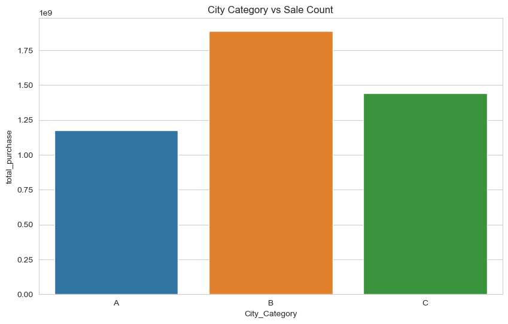

```python
plt.figure(figsize=(10, 6))
sns.barplot(x='City_Category', y='total_purchase', data=city_sales)
plt.title('City Category vs Sale Count');
```

**Insights**

- Above plot shows the difference in sales between different cities
- Even though City C has more users, City B had higher sales

# Hypothesis Testing

```python
critical_value = norm.ppf(0.95 + (1-0.95)/2)

confidence_intervals= ["90","95","99"]
sample_sizes=[300,3000,30000]
def calc_sample_mean(data, no_of_sample_means,number_of_samples):
    mean = []
    for i in range(no_of_sample_means):
        sample = data.sample(n=number_of_samples, replace=True)
        sample_mean=sample.mean()
        mean.append(sample_mean)
    return mean

def generate_confidence_intervals(data, standard_deviation_population):
    # standard_error_sample=standard_deviation_population/np.sqrt(5000)
    # margin_of_error = critical_value * standard_error_sample
    # data_mean = np.mean(data)
    # confidence_interval = [data_mean-margin_of_error, data_mean+margin_of_error]
    confidence_interval = {
        "90": np.percentile(data, [5, 95]),
        "95": np.percentile(data, [2.5, 97.5]),
        "99":np.percentile(data, [0.5, 99.5])
        }
    return confidence_interval

def generate_mini_report(all_details):
    data=all_details["data"]
    print("================== Full Data ==================")
    mean_population = data.mean(axis=0)
    standard_deviation_population = data.std(axis=0)
    confidence_interval_population = generate_confidence_intervals(data,standard_deviation_population)
    print(f"Poulation Mean: {mean_population},\nPoulation Standard Deviation: {standard_deviation_population}")
    print(f"=> Confidence Interval for full data")
    for ci in confidence_intervals:
        print(f"Confidence Interval for {ci}: {confidence_interval_population[ci]}")
    print("\n================== Sample Means ==================")
    mean_sample_1=calc_sample_mean(data, no_of_sample_means=5000, number_of_samples=300)
    mean_sample_2=calc_sample_mean(data, no_of_sample_means=5000, number_of_samples=3000)
    mean_sample_3=calc_sample_mean(data, no_of_sample_means=5000, number_of_samples=30000)
    print(f"Sample Mean for 300: {np.mean(mean_sample_1)},\nSample Mean for 3000: {np.mean(mean_sample_2)},
          \nSample Mean for 30000: {np.mean(mean_sample_3)}")
    print("\n================== Confidence Intervals ==================")

    confidence_interval_1 =  generate_confidence_intervals(mean_sample_1,standard_deviation_population)
    confidence_interval_2 =  generate_confidence_intervals(mean_sample_2,standard_deviation_population)
    confidence_interval_3 =  generate_confidence_intervals(mean_sample_3,standard_deviation_population)

    for ss in sample_sizes:
        print(f"\n=> Confidence Interval for {ss}")
        for ci in confidence_intervals:
            print(f"Confidence Interval for {ci}: {confidence_interval_1[ci]}")

    output={
        "standard_deviation_population":standard_deviation_population,
        "sample_300":{
            "mean_sample":mean_sample_1,
            "confidence_interval":confidence_interval_1
        },
        "sample_3000":{
            "mean_sample":mean_sample_2,
            "confidence_interval":confidence_interval_2
        },
        "sample_30000":{
            "mean_sample":mean_sample_3,
            "confidence_interval":confidence_interval_3
        },
        "sample_all":{
            "mean_sample":data,
            "confidence_interval":confidence_interval_population
        }
    }
    return output


def plot_purchase_distribution(data_report, labels, ci):
    sample_sizes = ["sample_300", "sample_3000", "sample_30000"]

    fig, axes = plt.subplots(1, 3, figsize=(20, 5), sharey=True)

    for i, sample_size in enumerate(sample_sizes):
        data1 = data_report[0][sample_size]["mean_sample"]
        data2 = data_report[1][sample_size]["mean_sample"]

        sns.kdeplot(data1, ax=axes[i], label=labels[0], color='red')
        sns.kdeplot(data2, ax=axes[i], label=labels[1], color='teal')

        ci1 = data_report[0][sample_size]["confidence_interval"][ci]
        ci2 = data_report[1][sample_size]["confidence_interval"][ci]

        axes[i].axvline(x=ci1[0], color='tomato', linestyle='--', label=f'{labels[0]} Confidence Interval')
        axes[i].axvline(x=ci1[1], color='tomato', linestyle='--')
        axes[i].axvline(x=ci2[0], color='green', linestyle='--', label=f'{labels[1]} Confidence Interval')
        axes[i].axvline(x=ci2[1], color='green', linestyle='--')

        axes[i].set_xlabel(f'Sample Base Purchase (Sample size = {sample_size.split("_")[1]})')

    plt.legend(bbox_to_anchor=(-0.8, -0.2), loc='upper center', ncol=2)

    axes[0].set_ylabel('Probability Density')
    fig.suptitle(f'Purchase distribution for {labels[0]} and {labels[1]} with Confidence Intervals of {ci}%', fontsize=20)

    plt.show()
```

```python
reduced_data_gender = db.sql("""
    select User_ID, Gender, sum(Purchase) Purchase from df group by User_ID, Gender
""").to_df()
reduced_data_maritial_status = db.sql("""
    select User_ID, Marital_Status, sum(Purchase) Purchase from df group by Marital_Status, User_ID
""").to_df()
reduced_data_age = db.sql("""
    select User_ID, Age, sum(Purchase) Purchase from df group by Age, User_ID
""").to_df()
```

```python
male_purchase_data=reduced_data_gender.loc[reduced_data_gender['Gender']=='M']["Purchase"]
female_purchase_data=reduced_data_gender.loc[reduced_data_gender['Gender']=='F']["Purchase"]
married_purchase_data=reduced_data_maritial_status.loc[reduced_data_maritial_status['Marital_Status']==1]["Purchase"]
single_purchase_data=reduced_data_maritial_status.loc[reduced_data_maritial_status['Marital_Status']==0]["Purchase"]
```

## Effect of Gender on Purchases

### Define hypothesis

- Ho = Women spend less than or equal to men
- Ha = Women spend more than men

```python
male_purchase_data.describe()
female_purchase_data.describe()
```

```
count    4.225000e+03
mean     8.141565e+05
std      8.899806e+05
min      3.502400e+04
25%      2.200000e+05
50%      4.934140e+05
75%      1.068209e+06
max      9.008191e+06
Name: Purchase, dtype: float64
```

```
count    1.666000e+03
mean     6.393897e+05
std      7.418809e+05
min      4.394300e+04
25%      1.756582e+05
50%      3.610935e+05
75%      7.862822e+05
max      5.381441e+06
Name: Purchase, dtype: float64
```

**Observations**

- Above data shows the population means of purchase data for male and female customers

### Male data analysis

```python
male_purchase_data_report = generate_mini_report({"data": male_purchase_data})
```

```
================== Full Data ==================
Poulation Mean: 814156.4904142012,
Poulation Standard Deviation: 889980.6238453629
=> Confidence Interval for full data
Confidence Interval for 90: [ 105041.  2644843.2]
Confidence Interval for 95: [  89860.  3395068.2]
Confidence Interval for 99: [  61671.08 4817056.36]

================== Sample Means ==================
Sample Mean for 300: 812791.0653293333,
Sample Mean for 3000: 814318.7961082667,
Sample Mean for 30000: 814261.2487411

================== Confidence Intervals ==================

=> Confidence Interval for 300
Confidence Interval for 90: [730285.67383333 900579.70816667]
Confidence Interval for 95: [716156.01575    920001.72183333]
Confidence Interval for 99: [688048.55615    953068.59228333]

=> Confidence Interval for 3000
Confidence Interval for 90: [730285.67383333 900579.70816667]
Confidence Interval for 95: [716156.01575    920001.72183333]
Confidence Interval for 99: [688048.55615    953068.59228333]

=> Confidence Interval for 30000
Confidence Interval for 90: [730285.67383333 900579.70816667]
Confidence Interval for 95: [716156.01575    920001.72183333]
Confidence Interval for 99: [688048.55615    953068.59228333]
```

**Observations**

- Above data shows the population means and confidence intervals of males for different sample sizes

### Female data analysis

```python
female_purchase_data_report = generate_mini_report({"data": female_purchase_data})
```

```
================== Full Data ==================
Poulation Mean: 639389.6548619447,
Poulation Standard Deviation: 741880.916768428
=> Confidence Interval for full data
Confidence Interval for 90: [  92706.75 2212421.25]
Confidence Interval for 95: [  78025.5   2870749.625]
Confidence Interval for 99: [  56585.35 3958352.  ]

================== Sample Means ==================
Sample Mean for 300: 639511.9935346666,
Sample Mean for 3000: 639268.1466572,
Sample Mean for 30000: 639413.1769396601

================== Confidence Intervals ==================

=> Confidence Interval for 300
Confidence Interval for 90: [570546.92366667 713737.56083333]
Confidence Interval for 95: [556339.908  728539.2035]
Confidence Interval for 99: [536836.75816667 756421.21296667]

=> Confidence Interval for 3000
Confidence Interval for 90: [570546.92366667 713737.56083333]
Confidence Interval for 95: [556339.908  728539.2035]
Confidence Interval for 99: [536836.75816667 756421.21296667]

=> Confidence Interval for 30000
Confidence Interval for 90: [570546.92366667 713737.56083333]
Confidence Interval for 95: [556339.908  728539.2035]
Confidence Interval for 99: [536836.75816667 756421.21296667]
```

**Observations**

- Above data shows the population means and confidence intervals of females for different sample sizes

### Confidence Interval Analysis

```python
m_all= male_purchase_data_report["sample_all"]["confidence_interval"]["95"][1] - male_purchase_data_report["sample_all"]["confidence_interval"]["95"][0]
f_all= female_purchase_data_report["sample_all"]["confidence_interval"]["95"][1] - female_purchase_data_report["sample_all"]["confidence_interval"]["95"][0]
print(f"Confidence_interval width for men : {m_all}\nConfidence_interval width for females : {f_all}")
```

```
Confidence_interval width for men : 3305208.199999999
Confidence_interval width for females : 2792724.125
```

**Insights**

- Above data shows that there is some difference in confidence interval widths between male and female customers for same sample count.
- The confidence interval for male is wider than the confidence interval for female. This is because there is greater variance in purchase data for men

### Plotting

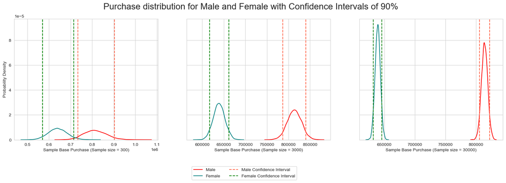

```python
plot_purchase_distribution([male_purchase_data_report, female_purchase_data_report], ['Male', 'Female'], '90')
```

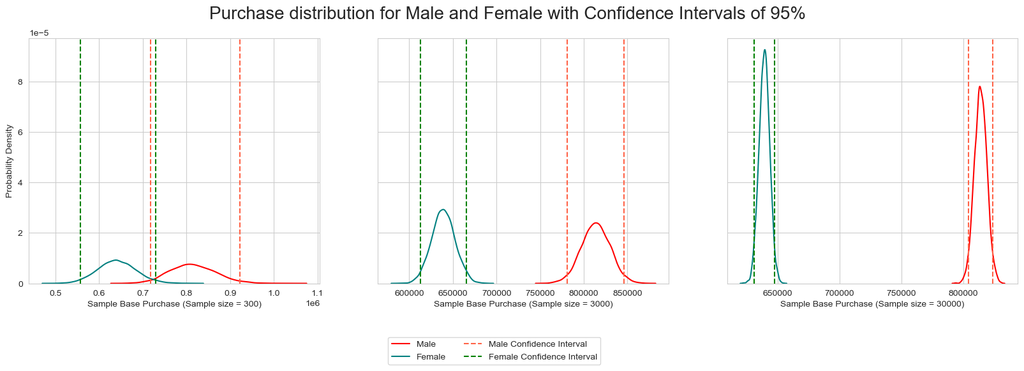

```python
plot_purchase_distribution([male_purchase_data_report, female_purchase_data_report], ['Male', 'Female'], '95')
```

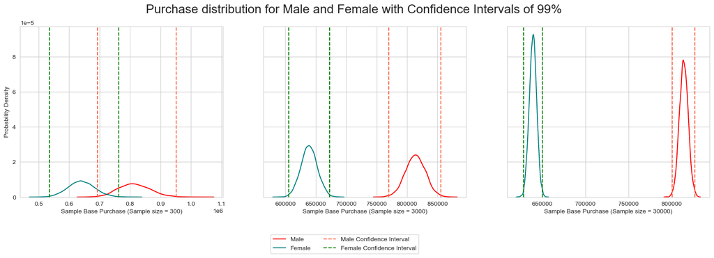

```python
plot_purchase_distribution([male_purchase_data_report, female_purchase_data_report], ['Male', 'Female'], '99')
```

**Insights**

Above plots show distribution for different sample sizes

- We can see that the purchase distribution of women is less than men.
- We can also see that confidence interval decreases in width as the number of the samples increases.

### 2 sample Z Test

```python
male_data=male_purchase_data_report["sample_30000"]["mean_sample"]
female_data = female_purchase_data_report["sample_30000"]["mean_sample"]
mean_men = np.mean(male_data)
mean_women = np.mean(female_data)
# se_men = np.std(male_data, ddof=1)/ np.sqrt(len(male_data))
# se_women = np.std(female_data, ddof=1) / np.sqrt(len(female_data))
pooled_SE = np.sqrt(np.std(male_data, ddof=1)**2/len(male_data) +  np.std(female_data, ddof=1)**2/len(female_data))
z_score = (mean_women - mean_men) / pooled_SE
p_value =1-norm.cdf(z_score)
z_score, p_value
```

```
(-1866.4479177949604, 1.0)
```

```python
alpha = 0.05
if p_value < alpha:
    print("Reject the null hypothesis")
else:
    print("Fail to reject the null hypothesis")
```

```
Fail to reject the null hypothesis
```

### T Test

```python
t_stat,pval = ttest_ind(female_purchase_data_report["sample_30000"]["mean_sample"],
                        male_purchase_data_report["sample_30000"]["mean_sample"], alternative="greater")
t_stat,pval
```

```
(-1866.4479177949606, 1.0)
```

```python
alpha = 0.05
if pval < alpha:
    print("Reject the null hypothesis")
else:
    print("Fail to reject the null hypothesis")
```

```
Fail to reject the null hypothesis
```

## Effect of Maritial Status on Purchases

### Define hypothesis

- Ho = No difference in spending amounts between married and single
- Ha = There is a difference in spending amounts between married and single

### Married user data analysis

```python
married_purchase_data_report = generate_mini_report({"data": married_purchase_data})
```

```
================== Full Data ==================
Poulation Mean: 746053.6026677445,
Poulation Standard Deviation: 850263.2921095208
=> Confidence Interval for full data
Confidence Interval for 90: [ 100160.5 2518728.2]
Confidence Interval for 95: [  84469.625 3295891.875]
Confidence Interval for 99: [  60640.815 4774602.69 ]

================== Sample Means ==================
Sample Mean for 300: 744804.1585520001,
Sample Mean for 3000: 745899.7278186666,
Sample Mean for 30000: 746042.2245121533

================== Confidence Intervals ==================

=> Confidence Interval for 300
Confidence Interval for 90: [668466.74766667 829926.76883333]
Confidence Interval for 95: [654348.98633333 849063.23308333]
Confidence Interval for 99: [622500.53896667 883041.96876667]

=> Confidence Interval for 3000
Confidence Interval for 90: [668466.74766667 829926.76883333]
Confidence Interval for 95: [654348.98633333 849063.23308333]
Confidence Interval for 99: [622500.53896667 883041.96876667]

=> Confidence Interval for 30000
Confidence Interval for 90: [668466.74766667 829926.76883333]
Confidence Interval for 95: [654348.98633333 849063.23308333]
Confidence Interval for 99: [622500.53896667 883041.96876667]
```

**Observations**

- Above data shows the population means and confidence intervals of married users for different sample sizes

### Single user data analysis

```python
single_purchase_data_report = generate_mini_report({"data": single_purchase_data})
```

```
================== Full Data ==================
Poulation Mean: 778255.113842552,
Poulation Standard Deviation: 857061.306214359
=> Confidence Interval for full data
Confidence Interval for 90: [ 100754.4 2538139.2]
Confidence Interval for 95: [  85137.2 3208610.8]
Confidence Interval for 99: [  59745.92       4508696.64000001]

================== Sample Means ==================
Sample Mean for 300: 778928.039672,
Sample Mean for 3000: 778365.9602614,
Sample Mean for 30000: 778319.8659684401

================== Confidence Intervals ==================

=> Confidence Interval for 300
Confidence Interval for 90: [702885.99716667 861555.925     ]
Confidence Interval for 95: [689218.10691667 878790.87083333]
Confidence Interval for 99: [665069.37485    912167.94438333]

=> Confidence Interval for 3000
Confidence Interval for 90: [702885.99716667 861555.925     ]
Confidence Interval for 95: [689218.10691667 878790.87083333]
Confidence Interval for 99: [665069.37485    912167.94438333]

=> Confidence Interval for 30000
Confidence Interval for 90: [702885.99716667 861555.925     ]
Confidence Interval for 95: [689218.10691667 878790.87083333]
Confidence Interval for 99: [665069.37485    912167.94438333]
```

**Observations**

- Above data shows the population means and confidence intervals of single users for different sample sizes

### Plotting

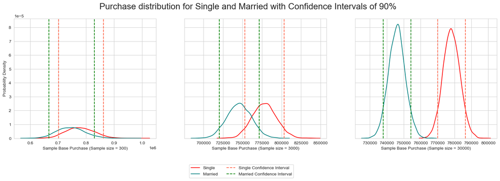

```python
plot_purchase_distribution([single_purchase_data_report, married_purchase_data_report], ['Single', 'Married'], '90')
```

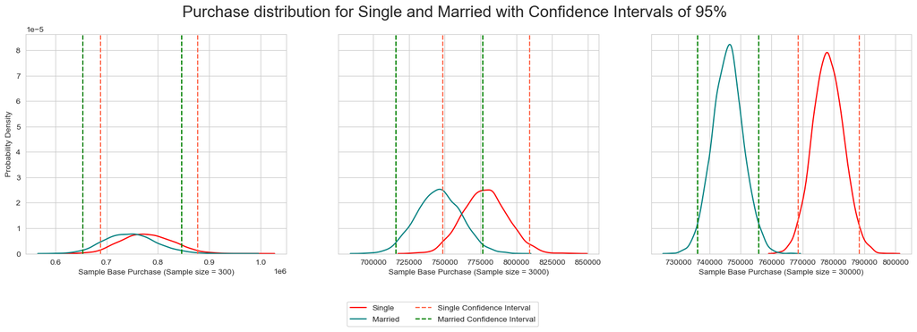

```python
plot_purchase_distribution([single_purchase_data_report, married_purchase_data_report], ['Single', 'Married'], '95')
```

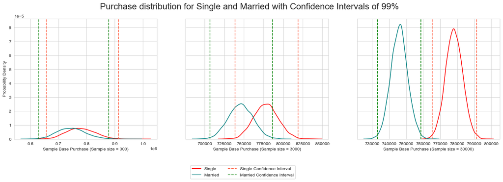

```python
plot_purchase_distribution([single_purchase_data_report, married_purchase_data_report], ['Single', 'Married'], '99')
```

**Insights**

- Above plots show the distribution of purchase data for married and unmarried users
- Above plot show that there is minor difference between married and unmarried users purchase data
- The width of confidence interval decreases as the number of the samples increases.

### T Test

```python
t_stat,pval = ttest_ind(single_purchase_data_report["sample_30000"]["mean_sample"],
                        married_purchase_data_report["sample_30000"]["mean_sample"])
t_stat,pval
```

```
(322.2793781230446, 0.0)
```

```python
alpha = 0.05
if pval < alpha:
    print("Reject the null hypothesis")
else:
    print("Fail to reject the null hypothesis")
```

```
Reject the null hypothesis
```

**Insights**

- Using T test, the p value is **0**. This means that we reject the null hypothesis.It means that there is difference between married and unmarried users purchase data.
- Using both plotting and T test, we found out there is some difference between married and unmarried users purchase data.

## Effect of Age on Purchase

### Define hypothesis

- Ho = No difference in spending amounts between age groups
- Ha = There is a difference in spending amounts between age groups

```python
age_cats=df["Age"].unique().to_list()
age_cats
```

```
['0-17', '55+', '26-35', '46-50', '51-55', '36-45', '18-25']
```

### Age Group Analysis

```python
reduced_data_age[reduced_data_age['Age'] == "55+"]["Purchase"].mean()
```

```
473105.95967741933
```

```python
age_data_dict={}
for cat in age_cats:
    data = reduced_data_age[reduced_data_age['Age'] == cat]["Purchase"]
    print(f"\n\nAge Category: {cat} ")
    age_data_dict[cat] = generate_mini_report({"data": data})
```

```
Age Category: 0-17
================== Full Data ==================
Poulation Mean: 546507.1651376147,
Poulation Standard Deviation: 620184.3525167555
=> Confidence Interval for full data
Confidence Interval for 90: [  90353.05 1501713.65]
Confidence Interval for 95: [  83321.225 1868191.7  ]
Confidence Interval for 99: [  69622.83 3353020.31]

================== Sample Means ==================
Sample Mean for 300: 546423.0730593334,
Sample Mean for 3000: 546606.2223684667,
Sample Mean for 30000: 546488.0495021

================== Confidence Intervals ==================

=> Confidence Interval for 300
Confidence Interval for 90: [489450.00966667 605989.61633333]
Confidence Interval for 95: [480437.21366667 619366.82241667]
Confidence Interval for 99: [459872.2587 644810.3554]

=> Confidence Interval for 3000
Confidence Interval for 90: [489450.00966667 605989.61633333]
Confidence Interval for 95: [480437.21366667 619366.82241667]
Confidence Interval for 99: [459872.2587 644810.3554]

=> Confidence Interval for 30000
Confidence Interval for 90: [489450.00966667 605989.61633333]
Confidence Interval for 95: [480437.21366667 619366.82241667]
Confidence Interval for 99: [459872.2587 644810.3554]


Age Category: 55+
================== Full Data ==================
Poulation Mean: 473105.95967741933,
Poulation Standard Deviation: 555349.855178293
=> Confidence Interval for full data
Confidence Interval for 90: [  89741.05 1373461.05]
Confidence Interval for 95: [  73622.85 1768079.5 ]
Confidence Interval for 99: [  58885.245 3208304.63 ]
```

[output cut: 167 more lines]

```

=> Confidence Interval for 300
Confidence Interval for 90: [681103.46183333 833323.13683333]
Confidence Interval for 95: [666459.01441667 851231.75266667]
Confidence Interval for 99: [641266.08275    885218.68943333]

=> Confidence Interval for 3000
Confidence Interval for 90: [681103.46183333 833323.13683333]
Confidence Interval for 95: [666459.01441667 851231.75266667]
Confidence Interval for 99: [641266.08275    885218.68943333]

=> Confidence Interval for 30000
Confidence Interval for 90: [681103.46183333 833323.13683333]
Confidence Interval for 95: [666459.01441667 851231.75266667]
Confidence Interval for 99: [641266.08275    885218.68943333]
```

**Observations**

- Above data shows the population means and confidence intervals of different age groups for different sample sizes

```python
def plot(ci):
    fig, axes = plt.subplots(1, 3, figsize=(20, 5), sharey=True)

    for cat in age_cats:
        kde_plot=sns.kdeplot(age_data_dict[cat]["sample_300"]["mean_sample"], ax=axes[0], label=cat)
        line_color = kde_plot.get_lines()[-1].get_c()
        axes[0].axvline(x=age_data_dict[cat]["sample_300"]["confidence_interval"][ci][0], color=line_color,  linestyle=':')
        axes[0].axvline(x=age_data_dict[cat]["sample_300"]["confidence_interval"][ci][1], color=line_color, linestyle=':');
    axes[0].set_xlabel(f'Sample Base Purchase (Sample size = 300)')

    for cat in age_cats:
        kde_plot=sns.kdeplot(age_data_dict[cat]["sample_3000"]["mean_sample"], ax=axes[1], label=cat)
        line_color = kde_plot.get_lines()[-1].get_c()
        axes[1].axvline(x=age_data_dict[cat]["sample_3000"]["confidence_interval"][ci][0], color=line_color, linestyle=':')
        axes[1].axvline(x=age_data_dict[cat]["sample_3000"]["confidence_interval"][ci][1], color=line_color, linestyle=':');
    axes[1].set_xlabel(f'Sample Base Purchase (Sample size = 3000)')

    for cat in age_cats:
        kde_plot=sns.kdeplot(age_data_dict[cat]["sample_30000"]["mean_sample"], ax=axes[2], label=cat)
        line_color = kde_plot.get_lines()[-1].get_c()
        axes[2].axvline(x=age_data_dict[cat]["sample_30000"]["confidence_interval"][ci][0], color=line_color, linestyle=':')
        axes[2].axvline(x=age_data_dict[cat]["sample_30000"]["confidence_interval"][ci][1], color=line_color, linestyle=':');

    axes[2].set_xlabel(f'Sample Base Purchase (Sample size = 30000)')


    plt.legend(bbox_to_anchor=(-0.8, -0.2), loc='upper center', ncol=2)
    fig.suptitle(f'Purchase distribution for Age Categories with Confidence Interval {ci}%', fontsize=20)

    # plt.tight_layout()
    plt.show();
```

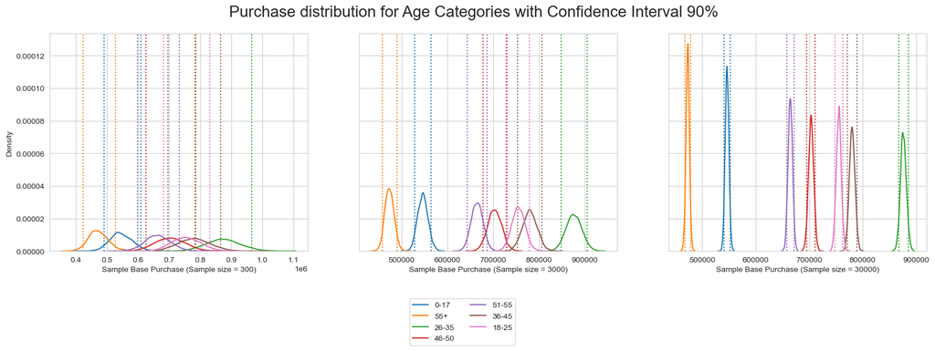

```python
plot("90")
```

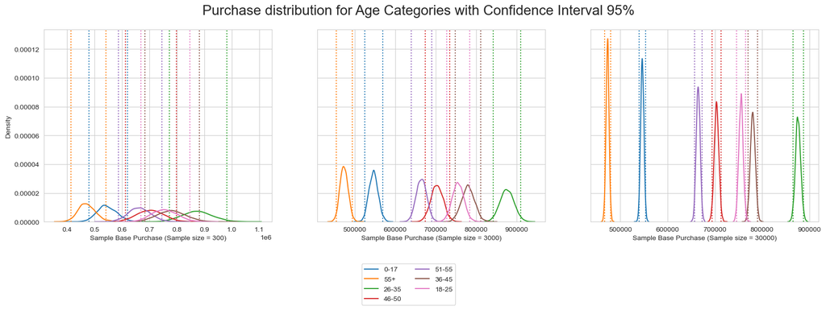

```python
plot("95")
```

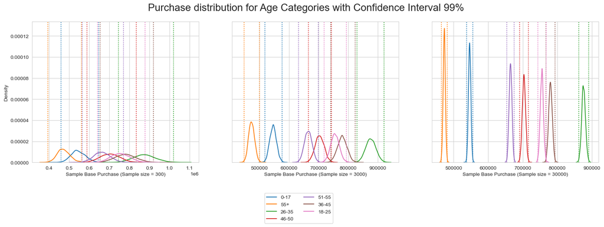

```python
plot("99")
```

**Insights**

- Above plots show distribution of all age group for purchase with different sample count
- Theere appears to be significant difference between age group and purchase data
- Age group 55+ is least spending group
- Age group 26-35 is highest spending group
- As the sample count increases the width of confidence interval decreases.

#### Anova Test

```python
mean_30000_data=[]
for age_cat in age_cats:
    mean_30000_data.append(age_data_dict[age_cat]["sample_30000"]["mean_sample"])
```

```python
f_statistic, pval = f_oneway(mean_30000_data[0], mean_30000_data[1],mean_30000_data[2],
                             mean_30000_data[3], mean_30000_data[4], mean_30000_data[5], mean_30000_data[6])
f_statistic, pval
```

```
(4775042.425122179, 0.0)
```

```python
alpha = 0.05
if pval < alpha:
    print("Reject the null hypothesis")
else:
    print("Fail to reject the null hypothesis")
```

```
Reject the null hypothesis
```

**Insights**

- Using annova test we can say that there is a significant difference between age group and purchase data
- By using both plotting and annova test, we found out there is a significant difference in spending between age group

# Recommendations

Below is the summary of customer spending patterns and potential strategies to increase sales:

**User Related**

- Male customers tend to spend more than female customers. In order to increase female customer spending, bigger discounts can be offered to female customers on existing products.
- Married customers tend to spend less than single customers. Offering couple discounts and adding small free toys as a gift for customers with kids can help boost spending among married customers.
- Customers aged 55 and above tend to spend the least. To encourage spending among older customers, bigger discounts can be offered, and delivery fees can be reduced or eliminated entirely.
- Customers between the ages of 26 and 35 tend to spend the most. Increasing social media ads and promotions can help acquire even more customers from this age group.

**Product Related**

- Product categories 1, 5, and 8 are the most profitable categories. Offering discounts and promotions on other categories and changing their placement in store or online can help increase sales.
- There should be more female only products in each category.

**City Related**

- City B has highest number of sales, City Category C has the highest number of users, while City A has the lowest user count. To increase sales in City A, higher discounts can be applied, and more promotional campaigns can be implemented.
- Customers who have been living in their current city for one year tend to be the biggest spenders. Customers who have been living in the same city for two, three, or four years tend to spend less. Implementing a loyalty program can help regain these customers.

**Occupation Related**

- Occupations 0, 4, and 7 have the highest number of users, while Occupation 8 has the lowest. Partnering with organizations or companies to offer promotions or discounts on certain categories for their employees can help increase sales among customers in Occupation 8.